# Responses to Assignment 3

## Assignment Three: The Week Four Assignment

**WDI and `ggplot2`**

- Create an R Notebook of a Data Analysis containing the following and submit the rendered HTML file (eg. `a3_123456.nb.html` by replacing 123456 with your ID)
  1. create an R Notebook using the R Notebook Template in Moodle, save as `a3_123456.Rmd`,
  2. write your name and ID and the contents,
  3. run each code block,
  4. preview to create `a3_123456.nb.html`,
  5. submit `a3_123456.nb.html` to Moodle.
1. Choose at least one indicator of WDI
   - Information of the data: Name, Indicator, Description, Source, etc.
   - Download the data with `WDI`
   - Explain why you chose the indicator
   - List questions you want to study
2. Explore the data using visualization using `ggplot2`
   - Use a histogram (geom_histogram), boxplot (geom_boxplot), a scatter plot (geom_point), a line plot (geom_line)
   - For at least one chart, add title, and labels of axis, and add an explanation of it
3. Observations and difficulties encountered.

**Due:** 2023-01-16 23:59:00. Submit your R Notebook file in Moodle (The Third Assignment). Due on Monday!

# 1 Set up

Follow thw workflow explained in EDA4 on January 18.

## 1.1 EDA by R Studio: Step 1

In RStudio,

1.1. Project

- Create a new project: File > New Project; or
- Open a project: File > Open Project, Open Project in New Session, Open Recent Project
  - It is easier to find an existing project from: File > Recent Project
- *Check there is a file `project_name.Rproj` in your project folder (directory)*

1.2. data folder (directory) `data`

- Create a data folder: Press New Folder at the right bottom pane; or
- Confirm the data folder previously created: Press Files at the right bottom pane
- *If you follow 1, the data folder exists in your project folder*

1.3. Move (or copy) data for the project to the data folder

- If you downloaded the data, it is in your Download folder. Move it to `data`.
- *Check in your RStudio that your data is in `data`: Press Files at the right bottom pane and click `data`, the data folder.*

## 1.2 EDA by R Studio: Step 2

2.1. Project Notebook: Memo

- Create an R Notebook: File > New File > R Notebook
  - You can use R Notebook template in Moodle by moving the template (template.Rmd or template.nb.Rmd) file in your project folder or copy and paste the text file into your new R Notebook.
  - If you use template.nb.Rmd (R Notebook File), choose Open in Editor.
- Add descriptive title.

2.2. Setup Code Chunk

- Create a code chunk and add packages to use in the project and RUN the code.
  - library(tidyverse)
  - library(WDI)
  - or any other packages

```r
library(tidyverse)
library(WDI)
```

*When people read a paper, they want to know the minimal set of packages required to install. So it is better to load the packages by library() you actually need in the paper.*

2.3. Choose `Source` or `Visual` editor mode, and start editing Project Notebook

- Set up Headings such as: About, Data, Analysis and Visualizations, Conclusions
- Under About or Data, paste url of the sites and/or the data

2.4. Edit a new file by saving as for a report

- File > Save As…

# 2 General Comments

## 2.1 Varibles

We should know first about the variables. At least you must know if each of the variables is a categorical variable or a numerical variable.

## 2.2 Visualization

- What type of variation occurs within my variables?
- What type of covariation occurs between my variables?

# 3 World Development Indicators (WDI)

## 3.1 Setup

It is not a must, but it is good to run the following code chunk and use `wdi_cache` for `WDIsearch()` to update the mata data. See `WDIcache` help.

```r
wdi_cache <- WDIcache()
```

## 3.2 Indicators Used in Assignment Three

- NY.GDP.PCAP.KD: GDP per capita (constant 2015 US$)
- NY.GDP.MKTP.CD: GDP (current US$)
- NY.GDP.PCAP.KD.ZG: GDP per capita growth (annual%)
- SP.POP.TOTL: Total Population
- IP.JRN.ARTC.SC: Scientific and technical journal articles
- FP.CPI.TOTL.ZG: Inflation, consumer prices (% annual growth)
- DT.ODA.ODAT.PC.ZS: Net ODA received per capita (current US$)
- BX.KLT.DINV.CD.WD: Foreign direct investment, net inflows (BoP, current US$)
- MS.MIL.XPND.GD.ZS: Military expenditure (% of GDP)
- MS.MIL.TOTL.P1: Total Armed Forces Personnel
- SI.POV.MDIM: Multidimensional poverty headcount ratio (% of total population)
- SI.POV.NAHC: Poverty headcount ratio at national poverty lines (% of population)
- SI.POV.GINI: Gini index
- NY.GNS.ICTR.ZS: Gross savings (% of GDP)
- SL.UEM.TOTL.ZS: Unemployment, total (% of total labor force) (modeled ILO estimate)
- SP.URB.TOTL.IN.ZS (Urban population (% of total population))
- AG.LND.AGRI.ZS: Agricultural land (% of land area)
- SE.ADT.LITR.FE.ZS: Literacy rate, adult female (% of females ages 15 and above))
- SE.ADT.LITR.MA.ZS: Literacy rate, adult male (% of males ages 15 and above))
- SE.ADT.LITR.ZS: Literacy rate, adult total
- SE.ADT.1524.LT.FE.ZS: Literacy rate, youth female (% of females ages 15-24)
- SE.XPD.TOTL.GD.ZS: Government expenditure on education, total (% of GDP)
- SG.GEN.PARL.ZS: Proportion of seats held by women in national parliaments (%)

## 3.3 WDIsearch

We obtain the information of the data, i.e., meta data of WDI: Name, Indicator, Description, Source, etc. by `WDIsearch`.

- Usage

```
WDIsearch(string = "gdp", field = "name", short = TRUE, cache = NULL)
```

- Arguments
  - `string`: Character string. Search for this string using grep with ignore.case=TRUE.
  - `field`: Character string. Search this field. Admissible fields: ‘indicator’, ‘name’, ‘description’, ‘sourceDatabase’, ‘sourceOrganization’
  - `short`: TRUE: Returns only the indicator’s code and name. FALSE: Returns the indicator’s code, name, description, and source.
  - `cache`: Data list generated by the WDIcache function. If omitted, WDIsearch will search a local list of series.

If you follow the order of the arguments, you can omit argument names: `string`, `field`, `short`, `cache`.

- The simplest format 1.

```r
WDIsearch("NY.GNS.ICTR.ZS", "indicator")
```

|  | indicator | name |
| --- | --- | --- |
| 11497 | NY.GNS.ICTR.ZS | Gross savings (% of GDP) |

- The simplest format 2.

```r
WDIsearch("Literacy rate", "name")
```

|  | indicator | name |
| --- | --- | --- |
| 27 | 1.1_YOUTH.LITERACY.RATE | Literacy rate, youth total (% of people ages 15-24) |
| 8841 | IN.POV.LIT.RAT.FEMALE | Literacy Rate Female (%) |
| 8842 | IN.POV.LIT.RAT.MALE | Literacy Rate Male (%) |
| 8843 | IN.POV.LIT.RAT.RURL | Literacy rate, Rural (%) |
| 8844 | IN.POV.LIT.RAT.SLUMS.FEMALE.PCT | Literacy Rate in Slums-Female (%) |
| 8845 | IN.POV.LIT.RAT.SLUMS.MALE.PCT | Literacy Rate in Slums - Male (%) |
| 8846 | IN.POV.LIT.RAT.SLUMS.TOTL.PCT | Literacy Rate in Slums - Total (%) |
| 8847 | IN.POV.LIT.RAT.TOTL | Literacy Rate (%) |
| 8848 | IN.POV.LIT.RAT.URBN | Literacy rate, Urban (%) |
| 15160 | SE.ADT.1524.IL.FE.ZS | Illiteracy rate, youth female (% of females ages 15-24) |

[output cut: 67 more lines]

- Detailed with short = FALSE

```r
WDIsearch("IP.JRN.ARTC.SC", "indicator", FALSE)
```

|  | indicator | name | description | sourceDatabase | sourceOrganization |
| --- | --- | --- | --- | --- | --- |
| 8885 | IP.JRN.ARTC.SC | Scientific and technical journal articles | Scientific and technical journal articles refer to the number of scientific and engineering articles published in the following fields: physics, biology, chemistry, mathematics, clinical medicine, bio… | World Development Indicators | National Science Foundation, Science and Engineering Indicators. |

- You can use `wdi_cache` downloaded above to use the updated meta data.

```r
WDIsearch("Government expenditure on education", "name", FALSE, wdi_cache)
```

|  | indicator | name | description | sourceDatabase | sourceOrganization |
| --- | --- | --- | --- | --- | --- |
| 16703 | SE.XPD.PRIM.ZS | Expenditure on primary education (% of government expenditure on education) | Expenditure on primary education is expressed as a percentage of total general government expenditure on education. General government usually refers to local, regional and central governments. | World Development Indicators | UNESCO Institute for Statistics (http://uis.unesco.org/). Data as of February 2020. |
| 16707 | SE.XPD.SECO.ZS | Expenditure on secondary education (% of government expenditure on education) | Expenditure on secondary education is expressed as a percentage of total general government expenditure on education. General government usually refers to local, regional and central governments. | World Development Indicators | UNESCO Institute for Statistics (http://uis.unesco.org/). Data as of February 2020. |
| 16712 | SE.XPD.TERT.ZS | Expenditure on tertiary education (% of government expenditure on education) | Expenditure on tertiary education is expressed as a percentage of total general government expenditure on education. General government usually refers to local, regional and central governments. | World Development Indicators | UNESCO Institute for Statistics (http://uis.unesco.org/). Data as of February 2020. |
| 16713 | SE.XPD.TOTL.GB.ZS | Government expenditure on education, total (% of government expenditure) | General government expenditure on education (current, capital, and transfers) is expressed as a percentage of total general government expenditure on all sectors (including health, education, social s… | World Development Indicators | UNESCO Institute for Statistics (UIS). UIS.Stat Bulk Data Download Service. Accessed October 24, 2022. https://apiportal.uis.unesco.org/bdds. |
| 16714 | SE.XPD.TOTL.GD.ZS | Government expenditure on education, total (% of GDP) | General government expenditure on education (current, capital, and transfers) is expressed as a percentage of GDP. It includes expenditure funded by transfers from international sources to government.… | World Development Indicators | UNESCO Institute for Statistics (UIS). UIS.Stat Bulk Data Download Service. Accessed October 24, 2022. https://apiportal.uis.unesco.org/bdds. |
| 20830 | UIS.X.PPP.FSGOV | Government expenditure on education, PPP$ (millions) | Total general (local, regional and central) government expenditure on education (current, capital, and transfers), in millions PPP$ (at purchasing power parity), in nominal value. It includes expendit… | Education Statistics | UNESCO Institute for Statistics |
| 20831 | UIS.X.PPP.UK.FSGOV | Government expenditure on education not specified by level, PPP$ (millions) | Total general (local, regional and central) government expenditure on education (current, capital, and transfers) not specified by level, in millions PPP$ (at purchasing power parity), in nominal valu… | Education Statistics | UNESCO Institute for Statistics |
| 20840 | UIS.X.PPPCONST.FSGOV | Government expenditure on education, constant PPP$ (millions) | Total general (local, regional and central) government expenditure on education (current, capital, and transfers), in millions PPP$ (at purchasing power parity) in constant value (taking into account … | Education Statistics | UNESCO Institute for Statistics |
| 20841 | UIS.X.PPPCONST.UK.FSGOV | Government expenditure on education not specified by level, constant PPP$ (millions) | Total general (local, regional and central) government expenditure on education (current, capital, and transfers) not specified by level, in millions PPP$ (at purchasing power parity) in constant valu… | Education Statistics | UNESCO Institute for Statistics |
| 20850 | UIS.X.US.FSGOV | Government expenditure on education, US$ (millions) | Total general (local, regional and central) government expenditure on education (current, capital, and transfers) in millions US$ (nominal value). It includes expenditure funded by transfers from inte… | Education Statistics | UNESCO Institute for Statistics |

[output cut: 3 more lines]

## 3.4 Importing Data Using WDI

- The shortest form. The following is same as: `WDI(country = "all", indicator = "NY.GDP.PCAP.KD", start = 1960, end = NULL, extra = FALSE, cache = NULL, latest = NULL, language = "en)`

```r
WDI(indicator = "NY.GDP.PCAP.KD")
```

| country | iso2c | iso3c | year | NY.GDP.PCAP.KD |
| --- | --- | --- | --- | --- |
| Africa Eastern and Southern | ZH | AFE | 2021 | 1460.9184 |
| Africa Eastern and Southern | ZH | AFE | 2020 | 1437.3024 |
| Africa Eastern and Southern | ZH | AFE | 2019 | 1519.8800 |
| Africa Eastern and Southern | ZH | AFE | 2018 | 1529.0021 |
| Africa Eastern and Southern | ZH | AFE | 2017 | 1531.6508 |
| Africa Eastern and Southern | ZH | AFE | 2016 | 1533.2885 |
| Africa Eastern and Southern | ZH | AFE | 2015 | 1540.8504 |
| Africa Eastern and Southern | ZH | AFE | 2014 | 1538.2492 |
| Africa Eastern and Southern | ZH | AFE | 2013 | 1520.2672 |
| Africa Eastern and Southern | ZH | AFE | 2012 | 1499.2445 |

[output cut: 990 more lines]

- In order to use the downloaded data, we need to assign a name to it. It can be `df` if you download and use only one data, but it is better to assign the data to be a more descriptive name.

```r
df_gdppcap <- WDI(indicator = "NY.GDP.PCAP.KD")
df_gdppcap
```

| country | iso2c | iso3c | year | NY.GDP.PCAP.KD |
| --- | --- | --- | --- | --- |
| Africa Eastern and Southern | ZH | AFE | 2021 | 1460.9184 |
| Africa Eastern and Southern | ZH | AFE | 2020 | 1437.3024 |
| Africa Eastern and Southern | ZH | AFE | 2019 | 1519.8800 |
| Africa Eastern and Southern | ZH | AFE | 2018 | 1529.0021 |
| Africa Eastern and Southern | ZH | AFE | 2017 | 1531.6508 |
| Africa Eastern and Southern | ZH | AFE | 2016 | 1533.2885 |
| Africa Eastern and Southern | ZH | AFE | 2015 | 1540.8504 |
| Africa Eastern and Southern | ZH | AFE | 2014 | 1538.2492 |
| Africa Eastern and Southern | ZH | AFE | 2013 | 1520.2672 |
| Africa Eastern and Southern | ZH | AFE | 2012 | 1499.2445 |

[output cut: 990 more lines]

- If you want to use extra information such as `region`, `income`, `lending`, use `extra = TRUE`.

```r
df_gdppcap_extra <- WDI(indicator = "NY.GDP.PCAP.KD", extra = TRUE)
df_gdppcap_extra
```

| country | iso2c | iso3c | year | NY.GDP.PCAP.KD | status | lastupdated | region | capital | longitude | latitude | income | lending |
| --- | --- | --- | --- | --- | --- | --- | --- | --- | --- | --- | --- | --- |
| Afghanistan | AF | AFG | 2015 | 592.4765 |  | 2022-12-22 | South Asia | Kabul | 69.1761 | 34.5228 | Low income | IDA |
| Afghanistan | AF | AFG | 2011 | 551.0010 |  | 2022-12-22 | South Asia | Kabul | 69.1761 | 34.5228 | Low income | IDA |
| Afghanistan | AF | AFG | 2014 | 602.5170 |  | 2022-12-22 | South Asia | Kabul | 69.1761 | 34.5228 | Low income | IDA |
| Afghanistan | AF | AFG | 2013 | 608.3867 |  | 2022-12-22 | South Asia | Kabul | 69.1761 | 34.5228 | Low income | IDA |
| Afghanistan | AF | AFG | 2012 | 596.4428 |  | 2022-12-22 | South Asia | Kabul | 69.1761 | 34.5228 | Low income | IDA |
| Afghanistan | AF | AFG | 2007 | 429.4125 |  | 2022-12-22 | South Asia | Kabul | 69.1761 | 34.5228 | Low income | IDA |
| Afghanistan | AF | AFG | 2010 | 569.2827 |  | 2022-12-22 | South Asia | Kabul | 69.1761 | 34.5228 | Low income | IDA |
| Afghanistan | AF | AFG | 2009 | 512.4093 |  | 2022-12-22 | South Asia | Kabul | 69.1761 | 34.5228 | Low income | IDA |
| Afghanistan | AF | AFG | 2008 | 437.4200 |  | 2022-12-22 | South Asia | Kabul | 69.1761 | 34.5228 | Low income | IDA |
| Afghanistan | AF | AFG | 2003 | 363.1015 |  | 2022-12-22 | South Asia | Kabul | 69.1761 | 34.5228 | Low income | IDA |

[output cut: 990 more lines]

## 3.5 Writing and reading a csv file

Since the data is generally huge, it is better to use a data saved in your computer. Before saving it check whether you have `data` folder (or directory) in you project folder. Use the `Files` tab of the right bottom pane. You should be able to see the project icon with Rproj at the end, your R Notebook file you are editing, and the `data` folder. Since `.csv` is automatically added, `write_csv(gdppcap_extra, "data/gdppcap_extra")` does the same as below.

```r
write_csv(gdppcap_extra, "data/gdppcap_extra.csv")
```

To read the data, run the next code chunk. You do not have to run the code `df_gdppcap_extra <- WDI(indicator = "NY.GDP.PCAP.KD", extra = TRUE)` again.

```r
gdppcap <- read_csv("data/gdppcap_extra.csv")
```

“data/gdpcap_extra.csv” is the way to express the name of the data `gdpcap_extra.csv` in csv format in the data folder.

## 3.6 `country` argument

If you want to import data for several countries, you can use `iso2c` codes of the countries.

```r
ASEAN <- c("BN", "ID", "KH", "LA", "MM", "MY", "PH", "SG")
df_gdppcap_asean <- WDI(ASEAN, "NY.GDP.PCAP.KD")
df_gdppcap_asean %>% distinct(country) %>% pull()
```

```
[1] "Brunei Darussalam" "Indonesia"         "Cambodia"
[4] "Lao PDR"           "Myanmar"           "Malaysia"
[7] "Philippines"       "Singapore"
```

```r
wdi_cache$country %>% filter(iso2c %in% ASEAN) %>% distinct(country) %>% pull()
```

```
[1] "Brunei Darussalam" "Indonesia"         "Cambodia"
[4] "Lao PDR"           "Myanmar"           "Malaysia"
[7] "Philippines"       "Singapore"
```

You can also use `wdi_cache$country`.

```r
wdi_cache$country
```

| iso3c | iso2c | country | region | capital | longitude | latitude | income | lending |
| --- | --- | --- | --- | --- | --- | --- | --- | --- |
| ABW | AW | Aruba | Latin America & Caribbean | Oranjestad | -70.0167 | 12.5167 | High income | Not classified |
| AFE | ZH | Africa Eastern and Southern | Aggregates |  |  |  | Aggregates | Aggregates |
| AFG | AF | Afghanistan | South Asia | Kabul | 69.1761 | 34.5228 | Low income | IDA |
| AFR | A9 | Africa | Aggregates |  |  |  | Aggregates | Aggregates |
| AFW | ZI | Africa Western and Central | Aggregates |  |  |  | Aggregates | Aggregates |
| AGO | AO | Angola | Sub-Saharan Africa | Luanda | 13.242 | -8.81155 | Lower middle income | IBRD |
| ALB | AL | Albania | Europe & Central Asia | Tirane | 19.8172 | 41.3317 | Upper middle income | IBRD |
| AND | AD | Andorra | Europe & Central Asia | Andorra la Vella | 1.5218 | 42.5075 | High income | Not classified |
| ARB | 1A | Arab World | Aggregates |  |  |  | Aggregates | Aggregates |
| ARE | AE | United Arab Emirates | Middle East & North Africa | Abu Dhabi | 54.3705 | 24.4764 | High income | Not classified |

[output cut: 289 more lines]

```r
wdi_cache$country %>% filter(iso2c %in% ASEAN) %>% pull(country)
```

```
[1] "Brunei Darussalam" "Indonesia"         "Cambodia"
[4] "Lao PDR"           "Myanmar"           "Malaysia"
[7] "Philippines"       "Singapore"
```

You can find iso2c codes from the downloaded data, or using wdi_cache$country

```r
wdi_cache$country %>%
  filter(country %in% c("Brunei Darussalam", "Indonesia", "Cambodia", "Lao PDR", "Myanmar", "Malaysia", "Philippines", "Singapore")) %>%
  pull(iso2c)
```

```
[1] "BN" "ID" "KH" "LA" "MM" "MY" "PH" "SG"
```

You can also find countries in some category.

```r
wdi_cache$country %>%
  filter(region == "South Asia") %>%
  pull(country)
```

```
[1] "Afghanistan" "Bangladesh"  "Bhutan"      "India"       "Sri Lanka"
[6] "Maldives"    "Nepal"       "Pakistan"
```

```r
wdi_cache$country %>%
  filter(income == "Lower middle income") %>%
  pull(iso2c)
```

```
 [1] "AO" "BJ" "BD" "BO" "BT" "CI" "CM" "CG" "KM" "CV" "DJ" "DZ" "EG" "FM" "GH"
[16] "HN" "HT" "ID" "IN" "IR" "KE" "KG" "KH" "KI" "LA" "LB" "LK" "LS" "MA" "MM"
[31] "MN" "MR" "NG" "NI" "NP" "PK" "PH" "PG" "PS" "SN" "SB" "SV" "ST" "SZ" "TJ"
[46] "TL" "TN" "TZ" "UA" "UZ" "VN" "VU" "WS" "ZW"
```

The following shows a list of indicators

```r
wdi_cache$series
```

| indicator | name | description | sourceDatabase | sourceOrganization |
| --- | --- | --- | --- | --- |
| 1.0.HCount.1.90usd | Poverty Headcount ($1.90 a day) | The poverty headcount index measures the proportion of the population with daily per capita income (in 2011 PPP) below the poverty line. | LAC Equity Lab | LAC Equity Lab tabulations of SEDLAC (CEDLAS and the World Bank). |
| 1.0.HCount.2.5usd | Poverty Headcount ($2.50 a day) | The poverty headcount index measures the proportion of the population with daily per capita income (in 2005 PPP) below the poverty line. | LAC Equity Lab | LAC Equity Lab tabulations of SEDLAC (CEDLAS and the World Bank). |
| 1.0.HCount.Mid10to50 | Middle Class ($10-50 a day) Headcount | The poverty headcount index measures the proportion of the population with daily per capita income (in 2005 PPP) below the poverty line. | LAC Equity Lab | LAC Equity Lab tabulations of SEDLAC (CEDLAS and the World Bank). |
| 1.0.HCount.Ofcl | Official Moderate Poverty Rate-National | The poverty headcount index measures the proportion of the population with daily per capita income below the official poverty line developed by each country. | LAC Equity Lab | LAC Equity Lab tabulations of data from National Statistical Offices. |
| 1.0.HCount.Poor4uds | Poverty Headcount ($4 a day) | The poverty headcount index measures the proportion of the population with daily per capita income (in 2005 PPP) below the poverty line. | LAC Equity Lab | LAC Equity Lab tabulations of SEDLAC (CEDLAS and the World Bank). |
| 1.0.HCount.Vul4to10 | Vulnerable ($4-10 a day) Headcount | The poverty headcount index measures the proportion of the population with daily per capita income (in 2005 PPP) below the poverty line. | LAC Equity Lab | LAC Equity Lab tabulations of SEDLAC (CEDLAS and the World Bank). |
| 1.0.PGap.1.90usd | Poverty Gap ($1.90 a day) | The poverty gap captures the mean aggregate income or consumption shortfall relative to the poverty line across the entire population. It measures the total resources needed to bring all the poor to t… | LAC Equity Lab | LAC Equity Lab tabulations of SEDLAC (CEDLAS and the World Bank). |
| 1.0.PGap.2.5usd | Poverty Gap ($2.50 a day) | The poverty gap captures the mean aggregate income or consumption shortfall relative to the poverty line across the entire population. It measures the total resources needed to bring all the poor to t… | LAC Equity Lab | LAC Equity Lab tabulations of SEDLAC (CEDLAS and the World Bank). |
| 1.0.PGap.Poor4uds | Poverty Gap ($4 a day) | The poverty gap captures the mean aggregate income or consumption shortfall relative to the poverty line across the entire population. It measures the total resources needed to bring all the poor to t… | LAC Equity Lab | LAC Equity Lab tabulations of SEDLAC (CEDLAS and the World Bank). |
| 1.0.PSev.1.90usd | Poverty Severity ($1.90 a day) | The poverty severity index combines information on both poverty and inequality among the poor by averaging the squares of the poverty gaps relative the poverty line | LAC Equity Lab | LAC Equity Lab tabulations of SEDLAC (CEDLAS and the World Bank). |

[output cut: 990 more lines]

The following is same as `WDIsearch("gdp per cap", "name")`. See WDIsearch help.

```r
wdi_cache$series %>% filter(grepl("gdp per cap", name, ignore.case = TRUE))
```

| indicator | name | description | sourceDatabase | sourceOrganization |
| --- | --- | --- | --- | --- |
| 6.0.GDPpc_constant | GDP per capita, PPP (constant 2011 international $) | GDP per capita based on purchasing power parity (PPP). PPP GDP is gross domestic product converted to international dollars using purchasing power parity rates. An international dollar has the same pu… | LAC Equity Lab | World Development Indicators (World Bank) |
| CC.GHG.MEMG.GC | Macro drivers of GHG emissions growth in the period 2012-2018 - GDP per capita | Data reflects the impact of GDP-per capita (as a macro-driver) to total emission growth (excluding LUCF) across the period 2012-2018. This data has been calculated by World Bank staff using greenhouse… | Country Climate and Development Report (CCDR) | Climate Watch. 2020. Washington, DC: World Resources Institute. Available online at: https://www.climatewatchdata.org. |
| FB.DPT.INSU.PC.ZS | Deposit insurance coverage (% of GDP per capita) |  | WDI Database Archives |  |
| NV.AGR.PCAP.KD.ZG | Real agricultural GDP per capita growth rate (%) | The growth rate of real per capita GDP in agriculture, expressed at an annual rate. | Africa Development Indicators | World Bank country economists. |
| NY.GDP.PCAP.CD | GDP per capita (current US$) | GDP per capita is gross domestic product divided by midyear population. GDP is the sum of gross value added by all resident producers in the economy plus any product taxes and minus any subsidies not … | World Development Indicators | World Bank national accounts data, and OECD National Accounts data files. |
| NY.GDP.PCAP.CN | GDP per capita (current LCU) | GDP per capita is gross domestic product divided by midyear population. GDP is the sum of gross value added by all resident producers in the economy plus any product taxes and minus any subsidies not … | World Development Indicators | World Bank national accounts data, and OECD National Accounts data files. |
| NY.GDP.PCAP.KD | GDP per capita (constant 2015 US$) | GDP per capita is gross domestic product divided by midyear population. GDP is the sum of gross value added by all resident producers in the economy plus any product taxes and minus any subsidies not … | World Development Indicators | World Bank national accounts data, and OECD National Accounts data files. |
| NY.GDP.PCAP.KD.ZG | GDP per capita growth (annual %) | Annual percentage growth rate of GDP per capita based on constant local currency. GDP per capita is gross domestic product divided by midyear population. GDP at purchaser's prices is the sum of gross … | World Development Indicators | World Bank national accounts data, and OECD National Accounts data files. |
| NY.GDP.PCAP.KN | GDP per capita (constant LCU) | GDP per capita is gross domestic product divided by midyear population. GDP at purchaser's prices is the sum of gross value added by all resident producers in the economy plus any product taxes and mi… | World Development Indicators | World Bank national accounts data, and OECD National Accounts data files. |
| NY.GDP.PCAP.PP.CD | GDP per capita, PPP (current international $) | This indicator provides per capita values for gross domestic product (GDP) expressed in current international dollars converted by purchasing power parity (PPP) conversion factor. GDP is the sum of gr… | World Development Indicators | International Comparison Program, World Bank \| World Development Indicators database, World Bank \| Eurostat-OECD PPP Programme. |

[output cut: 17 more lines]

# 4 Responses to Questions

## 4.1 Q1. How do we use histograms.

- [Histograms and frequency polygons](https://ggplot2.tidyverse.org/reference/geom_histogram.html)
- [Posit Cloud: Histograms](https://posit.cloud/learn/primers/3.3)

```r
wdi_cache$series %>% filter(indicator == "SG.GEN.PARL.ZS") %>% pull(name)
```

```
[1] "Proportion of seats held by women in national parliaments (%)"
```

```r
df_women_in_parl <- WDI(indicator = c(women_in_parl = "SG.GEN.PARL.ZS")) %>%
  drop_na(women_in_parl)
```

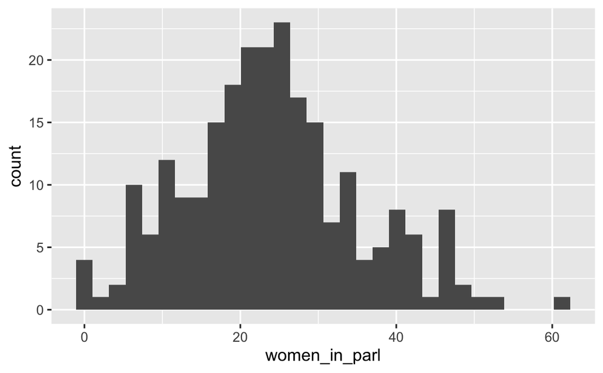

```r
df_women_in_parl %>% filter(year == 2020) %>%
  ggplot(aes(women_in_parl)) + geom_histogram()
```

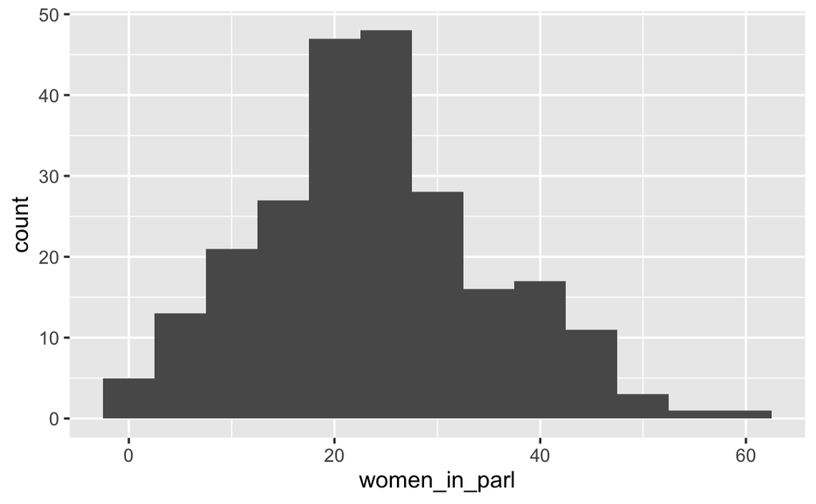

```r
df_women_in_parl %>% filter(year == 2020) %>%
  ggplot(aes(women_in_parl)) + geom_histogram(binwidth = 5)
```

```r
wdi_cache$series %>% filter(indicator == "IP.JRN.ARTC.SC") %>% pull(name)
```

```
[1] "Scientific and technical journal articles"
```

```r
df_stja <- WDI(indicator = c(stja = "IP.JRN.ARTC.SC"), extra = TRUE) %>%
  drop_na(stja)
```

Default of the number of bins is 30. Change and find an appropriate one.

```r
df_stja$year %>% summary()
```

```
   Min. 1st Qu.  Median    Mean 3rd Qu.    Max.
   2000    2004    2009    2009    2014    2018
```

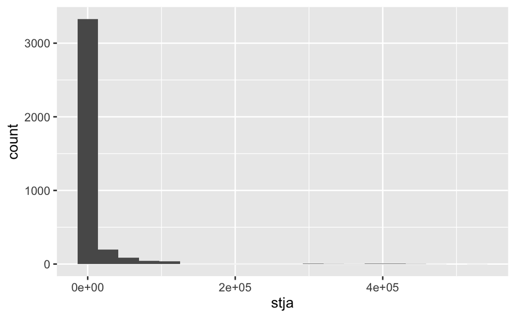

```r
df_stja %>% filter(income != "Aggregates") %>%
  ggplot(aes(stja)) + geom_histogram(bins = 20)
```

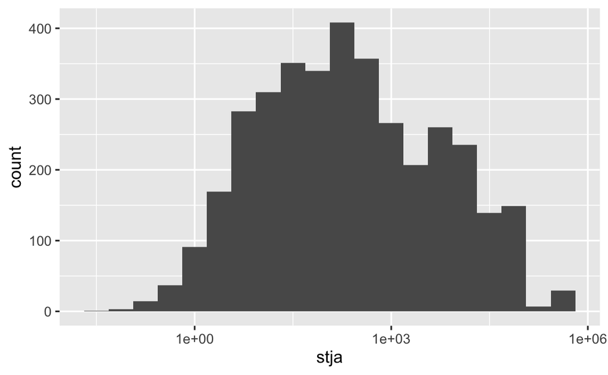

```r
df_stja %>% filter(income != "Aggregates", stja >0) %>%
  ggplot(aes(stja)) + geom_histogram(bins = 20) + scale_x_log10()
```

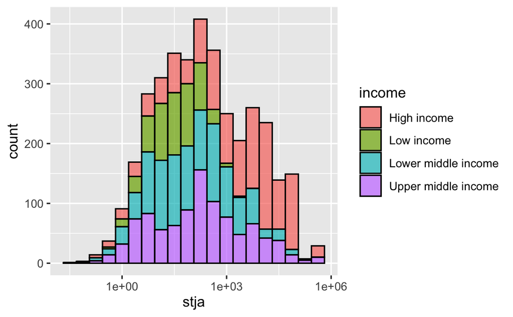

```r
df_stja %>% filter(income != "Aggregates", income != "Not classified", stja >0) %>%
  ggplot(aes(stja, fill = income)) + geom_histogram(alpha = 0.7, bins = 20, color = "black") + scale_x_log10()
```

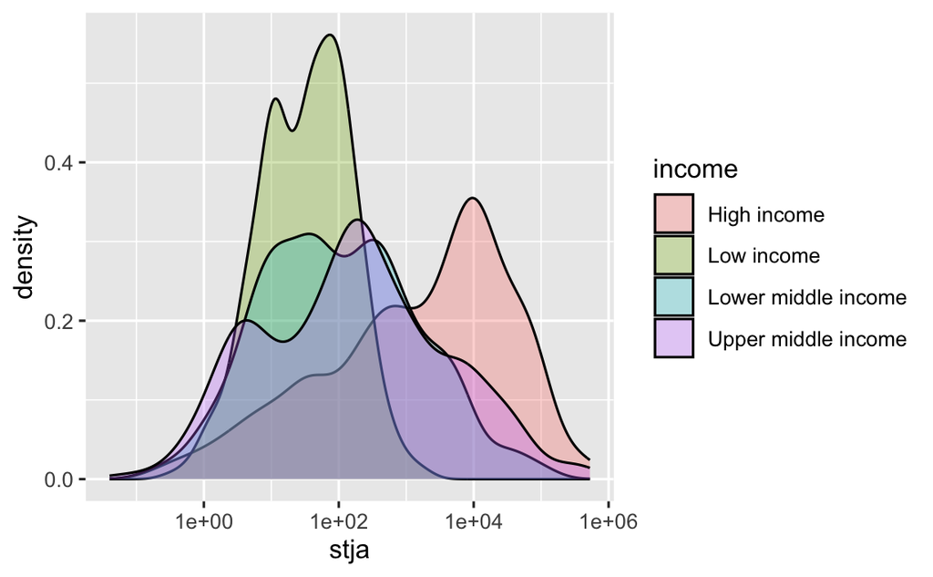

```r
df_stja %>% filter(income != "Aggregates", income != "Not classified", stja >0) %>%
  ggplot(aes(stja, fill = income)) + geom_density(alpha = 0.3) + scale_x_log10()
```

```r
wdi_cache$series %>% filter(indicator == "MS.MIL.XPND.GD.ZS") %>% pull(name)
```

```
[1] "Military expenditure (% of GDP)"
```

```r
df_milxpnd <- WDI(indicator = c(milxpnd = "MS.MIL.XPND.GD.ZS"), extra = TRUE) %>%
  drop_na(milxpnd)
```

Default of the number of bins is 30. Here I chose binwidth = 0.5 (%).

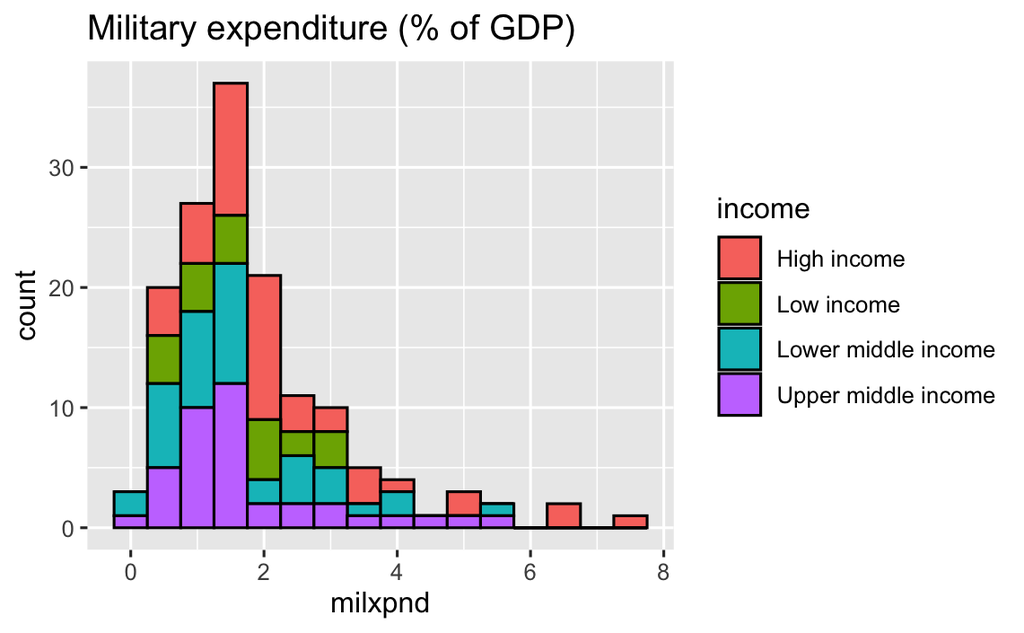

```r
df_milxpnd %>% filter(income != "Aggregates", year == 2021) %>%
  ggplot(aes(milxpnd, fill = income)) + geom_histogram(color = "black", binwidth = 0.5) +
  labs(title = "Military expenditure (% of GDP)")
```

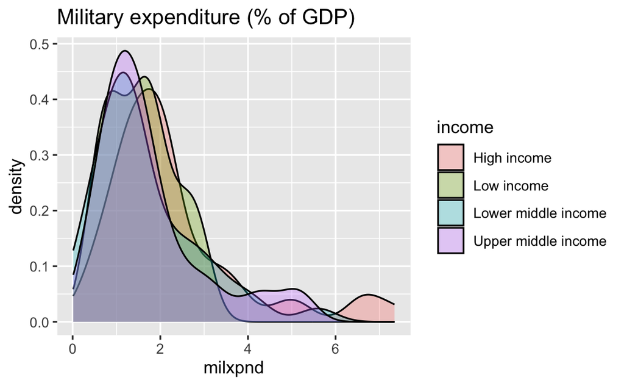

```r
df_milxpnd %>% filter(income != "Aggregates", income != "Not classified", year == 2021) %>%
  ggplot(aes(milxpnd, fill = income)) + geom_density(binwidth = 0.5, alpha = 0.3) +
  labs(title = "Military expenditure (% of GDP)")
```

## 4.2 Q2. Effect of unemployed rate under pandemic depending on income groups

```r
wdi_cache$series %>% filter(indicator == "SL.UEM.TOTL.ZS") %>% pull(name)
```

```
[1] "Unemployment, total (% of total labor force) (modeled ILO estimate)"
```

```r
df_ur <- WDI(indicator = c(ur = "SL.UEM.TOTL.ZS"),
             extra = TRUE, cache = wdi_cache) %>% drop_na(ur)
```

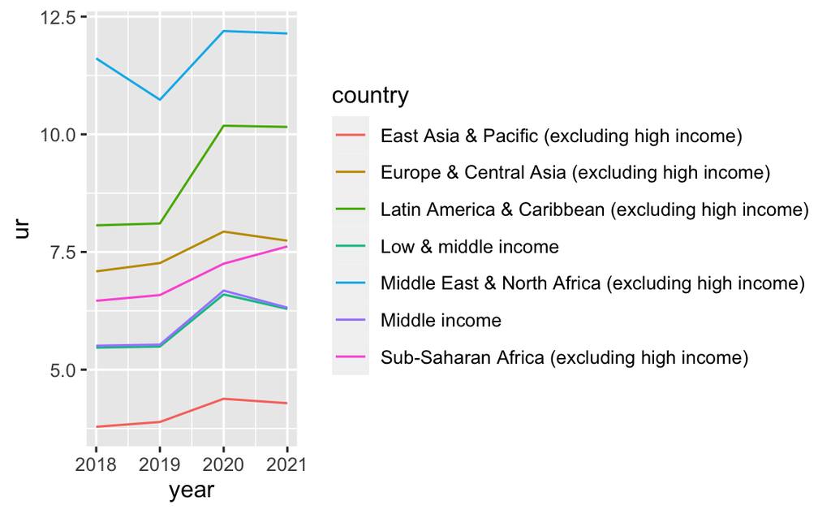

```r
df_ur %>% filter(income == "Aggregates") %>% filter(grepl('income', country)) %>%
  filter(year >= 2018) %>% ggplot() + geom_line(aes(x = year, y = ur, color = country))
```

## 4.3 Q3. Add values at each data point.

```r
wdi_cache$series %>% filter(indicator == "FP.CPI.TOTL.ZG") %>% pull(name)
```

```
[1] "Inflation, consumer prices (annual %)"
```

```r
df_infl <- WDI(country = c("VN","CN","JP"),
               indicator = c(inf = "FP.CPI.TOTL.ZG"), extra = TRUE) %>% drop_na(inf)
```

```r
df_infl_s <- df_infl %>% filter(year %in% c(2000, 2005, 2010, 2015, 2020),
                   country %in% c("Japan", "Vietnam", "China"))
df_infl_s
```

| country | iso2c | iso3c | year | inf | status | lastupdated | region | capital | longitude | latitude | income | lending |
| --- | --- | --- | --- | --- | --- | --- | --- | --- | --- | --- | --- | --- |
| China | CN | CHN | 2020 | 2.41942189 |  | 2022-12-22 | East Asia & Pacific | Beijing | 116.286 | 40.0495 | Upper middle income | IBRD |
| China | CN | CHN | 2015 | 1.43702381 |  | 2022-12-22 | East Asia & Pacific | Beijing | 116.286 | 40.0495 | Upper middle income | IBRD |
| China | CN | CHN | 2010 | 3.17532475 |  | 2022-12-22 | East Asia & Pacific | Beijing | 116.286 | 40.0495 | Upper middle income | IBRD |
| China | CN | CHN | 2005 | 1.77641408 |  | 2022-12-22 | East Asia & Pacific | Beijing | 116.286 | 40.0495 | Upper middle income | IBRD |
| China | CN | CHN | 2000 | 0.34781123 |  | 2022-12-22 | East Asia & Pacific | Beijing | 116.286 | 40.0495 | Upper middle income | IBRD |
| Japan | JP | JPN | 2020 | -0.02499583 |  | 2022-12-22 | East Asia & Pacific | Tokyo | 139.77 | 35.67 | High income | Not classified |
| Japan | JP | JPN | 2015 | 0.79527963 |  | 2022-12-22 | East Asia & Pacific | Tokyo | 139.77 | 35.67 | High income | Not classified |
| Japan | JP | JPN | 2010 | -0.72824321 |  | 2022-12-22 | East Asia & Pacific | Tokyo | 139.77 | 35.67 | High income | Not classified |
| Japan | JP | JPN | 2005 | -0.28294607 |  | 2022-12-22 | East Asia & Pacific | Tokyo | 139.77 | 35.67 | High income | Not classified |
| Japan | JP | JPN | 2000 | -0.67657868 |  | 2022-12-22 | East Asia & Pacific | Tokyo | 139.77 | 35.67 | High income | Not classified |

[output cut: 5 more lines]

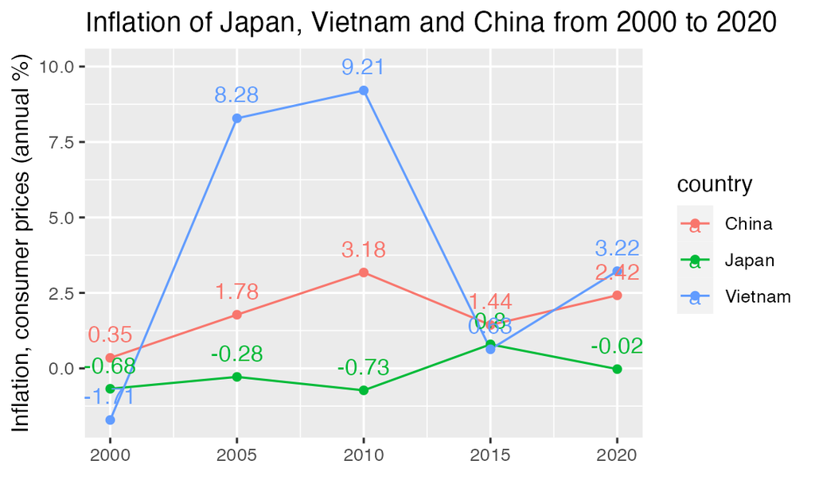

```r
df_infl_s %>%
  ggplot(aes(x = year, y = inf, color= country)) +
  geom_line() + geom_point() +
  geom_text(aes(label = round(inf,2)), nudge_y = 0.8) +
labs(title = "Inflation of Japan, Vietnam and China from 2000 to 2020",
     x = "", y = "Inflation, consumer prices (annual %)")
```